# Module 13: Business Analysis, Risk Identification and Initial Assessment

C. Lau

September 28, 2016

## Module 13 Objective

Discuss the framework for risk management and control within a company

- Discuss the **cultural aspects** of risk assessment and management including the **problems of bias**

Discuss the application of the risk management control cycle

- Relevance of **external influences** and **emerging risks**

Discuss how to **identify** **risks** and their **causes** and **implication**

Explain what is meant by **risk** and **uncertainty** and discuss different definitions and **concepts of risk**

ERM involves all risks faced by an organization

**First step**: To determine and understand what risks the org. face

- *Process of risk identification*

  Incl. considerations of why each risk **arises** and an **initial assessment** of the impact it could have on the org.

Module focus on the first part of the risk management control cycle

1. **Business analysis**:

   Need to understand and know the specific characteristics of the org. and its operating environment before risk can be identified comprehensively
2. **Risk identification**:

   Systematic process to identify the risks to which the org. is exposed
3. **Initial assessment of risk**:

   Initial evaluation of the risks (quant. & qual.) to facilitate prioritization of appropriate risk management actions

*Key discussion*:

- Implementation
- Methods and outputs of the process
- Issues involved in identifying emerging risks (the problem of bias)

(Again, this only covers up-to the initial assessment)

Note: language on identification, assessment, evaluation, quantification can be use as being distinct or overlap in meaning

## Risk Identification and Assessment

6 steps of a comprehensive **risk identification** and **initial assessment** process

1. *Business analysis*

   *Ensure* that the company has **clear business objectives**  
   (Or else difficult to establish what risks can impact on their achievement)

   Analyse its **operation** and its **wider environment**
   - **Business plan**
   - Company’s **structure** and system of **internal controls**
   - *Current* and *projected* **accounts** and accounting ratios
   - **Market information** (e.g. competitors actions and market share)
   - **Resources available** to the company
   - Legislative and **regulatory constraints**
   - General **economic environment**
2. *Identify the risks*

   Identify up & down side risk **structurally**

   Start with a review of the **findings of the business analysis** to identify any areas or `risk`, `uncertainty` or `opportunity`

   See next section for risk identification methods
3. *Obtain agreement*

   Obtain agreement (with other stakeholders?) on the **risks faced**, **relationships** between them, and identify **individuals who will be responsible** for each risk and its management
4. *Evaluate the risks*

   Evaluate in terms of **likelihood** and **severity** over a given time frame

   Can be done for both **gross** and **net of existing controls**

   Enable risks to be **prioritized** for further implementation of controls
5. *Produce a risk register*

   **Record the results** of this process in one place

   Next section will further discuss elements of the register
6. *Review the risk register regularly*

   Especially in times of change to ensure that it **remains up to date** and reflects the current risks faced by the company

### Benefits of the Process

Important first step in the RM process:

- *Enhances* **awareness** and **transparency** of risks
- Helps **transfer knowledge** and **improve understanding** across the org.
- Acts as a firm **base for subsequent risk analysis**, quantification and prioritization
- **Enhances the quality of reporting** to the Board and senior management

$\therefore$ Helps improves business decision making

### Requirements

Requirements to gain the benefits above:

- Need **senior sponsorship** of the RM program
- Be **consistent** on the standards used **overtime**
- Ensure **quantitative and qualitative** data is used so as to develop a comprehensive risk profile for the whole org.
- **Integrate** risk identification with the entire RM process
- **Demonstrate added value** (on top of meeting regulatory requirements)

### Risk Assessment Process

4 stage risk identification and assessment process (expansion of step 2 above)

1. *Foundation setting*
   - *Get* **executive sponsorship**
   - *Organize* and *plan* for **resources**  
     (e.g accountabilities and deadlines)
   - *Define* a **risk taxonomy**
   - *Build* a customized **risk identification and assessment tool**
   - **Educate** and train project teams and management

   **Potential pitfall**:
   - Lack of senior management buy-in and participation
   - Bad resources planning and allocation
   - Insufficient preparation lead to an inefficient or ineffective process
2. *Risk identification, assessment and prioritization*
   - **Understand** `business objective`, `risk appetite`, `regulatory` and `policy requirements`
   - Undertake **risk assessments**
     - Top down (e.g. interviews)
     - Bottom-up (e.g. workshops)
   - Produce risk reports and risk maps
   - **Prioritize** risk

   **Potential pitfall**:
   - Lack of clear business objectives or risk appetite
   - Focusing on consequences rather than **causes** of risk
   - **Inconsistent estimate** of frequency and severity
3. *Deep dives, risk quantification and managment*
   - Detailed assessments of of the **top risks** (prioritized from step 2.)
   - *Produce* **risk tolerance** statements and **track KRIs**
   - *Determine* **risk management strategies** and the **total cost of risk** (for pricing purpose)

   **Potential pitfall**:
   - Lack of prioritization of key risk
   - **Insufficient risk quantification**
   - Risk assessment **not translated into value adding action**
4. *Business and EMR integration*
   - **Link risk assessment** with both `strategic planning` and `business review processes`
   - **Integrate risk assessment** into *everyday business operations*  
     (e.g. pricing and capital allocation)
   - Conduct **scenario analysis** and **stress testing**
   - **Report** on risk
   - Creating and maintaining **loss/events databases**
   - Establish appropriate **risk-escalation policies**

   **Potential pitfall**:
   - **Restricting integration** to low level reports
   - **Failure to fundamentally change the business attitude** to risk management

See Lam App to Ch.23 with the **risk assessment self evalulation** checklist

- How well developed and mature is the copany’s risk identification and assessment
- Degree of integration of RM across the org.

## Risk Identification and Recording

### Risk Identification Tools

1. *SWOT Analysis*
   - Framework for generating ideas in a **structured** and comprehensive ways
   - Consider `strengths`, `weakness`, `opportunities`, and `threats`
   - Establish what risks the company faces
2. *Risk Checklist*
   - **List of risk** identified in the **past** or from **external source**

     Need to make sure the information is relevant and up to date
3. *Risk Prompt List*
   - List of different **categories of risk** to consider and examples of each
     - Can be produced at an industry wide level
   - List `situations` and `events` that have **previously emerged** and that should be considered
   - Similar to risk trigger questions
   - e.g. PEST(ELI) analysis that covers:  
     `Political`, `economic`, `social`, `technology` (`environmental`, `legal` and `industry`) risks
4. *Risk Taxonomy*
   - Structured way of **classifying risks** and *breaking* them down into **components**
   - Help to *ensure* that those involved in the process have a **common understanding of the terms used** in risk identification
   - **Less project specific** than a `checklist` and **less industry specific** than an `industry prompt list`
5. *Case Studies*
   - Can help to understand the impact of risks in a specific context
6. *Process Analysis*
   - Build **flow charts** that detail **business process** and **links** between them
   - Help identify the **risks that arise at each stage**
   - **Particularly suited to op-risk**

*Advantages* of the tools above:

- Provide a **clear structure** for the risk identification process
- *Improve* the **quality of the output** (vs a less structured process)

*Disadvantage* of the tools above:

- Results may still **not be comprehensive**  
  (e.g. due to bias in the process or the participants)

### Risk Identification Techniques

Activities must be **well planned** and supported by a **positive risk culture**

*Factors to consider on techniques*:

1. **Who**
   - Input is needed from **all areas of the business** to identify all risks and dependencies
   - Select a diverse mix of people (role, experience and seniority)
2. **How**
   - Workshop, questionnaires
   - Workshop types e.g. brainstorming
   - External help in facilitation of workshops or design of questionnaires

*Risk identification techniques*

1. *Brainstorming*

   Group of people generating ideas in a **free form** way
   - **Facilitated** by an external consultant
   - Requires all participants to be in the same location at the same time

   **Potential disadvantage**:
   - If poorly run, can lead to **group think**
   - **Uneven participation** can lead to an incomplete or biased identification of risks

   **Mitigation**:
   - Participants should come from various departments across the org. and have **different backgrounds**
   - **Outsiders** can bring fresh ideas even in specialist areas
2. *Independent group analysis*
   - Each risk is **presented** by a member of the group and is then **discussed* by the group
   - Each member then **rank each of the risk independently** (to avoid group think)
   - Results are combined to form an **overall ranking**

   **Potential disadvantage**:
   - **Unbalanced group** may produce a biased list of risk and rankings
3. *Surveys*

   Use online surveys to generate a wide range of responses cheaply and without collusion between participants
   - Doesn’t need everyone at the same place

   **Potential disadvantage**:
   - Problem of **framing**
     - Risk that the way the question is asked influences the response (can be mitigate by pilot surveys to help improve the design)
   - Poor **response rates**
   - Quality of the survey is only as good as both the **design and analysis of the response**

     e.g MC is easier to analyze but limit the range of possible responses
4. *Gap analysis*
   - Type of questionnaire designed to identify the company’s **current and desired risk exposures**
   - `Line manager` might be best to identify the **current risk** while the `Board` is best to identify **desired risk**

   **Potential disadvantage**:
   - **Difficult and costly** to engage the Board in such a process
5. *Delphi technique*

   A structured communication technique where the participants **answer questionnaires in 2 or more rounds**
   - After each round, a facilitator provides an anonymous summary of the output from the previous round as well as the reasons they provided for their judgement
   - Participants then revise their earlier answers in light of the replies of other members of the panel

   **Intention**:

   During the revise process the range of answers will decrease and the group will converge towards a consensus

   **Potential disadvantage**:
   - Time consuming and costly
6. *Interviews*

   Individuals are interviewed and the results collated by an independent external reviewer
   - Can immediately clarify on responses

   **Potential disadvantage**:
   - **Time consuming** and expensive  
     $\hookrightarrow$ Restrictions on the number of interviews
   - Having multiple interviewers can lead to **inconsistencies**
7. *Working groups*

   Small numbers of **interested individuals** are tasked with **considering a specific risk** (or group of risk)
   - Members are normally **specialists**
   - Scope can extend to analysis of the risk identified, esp. if they are unquantifiable

   **Potential disadvantage**:
   - Identification will be **narrow** rather than comprehensive (As they are all specialist)
   - Specialist might want to work at a **higher level of precision than the cost is justified**

### Risk Register

Risk should be collated in a risk register once identified

*Key elements of risk register*

- Labeling or **numbering system** to risk can be identify easily
- **Category** of risk
- **Description** of each risk (that is clear and understandable to all)
- **Initial** assessment of the **likelihood** and **impact** over an applicable time frame
- **Risk response action**

  (retain, remove, reduce, or transfer)

  Its cost and expected residual/secondary risk
- Individual involved in *monitoring* and *managing* the risk  
  (**Risk owner**)
- Document **control information**  
  (e.g. when was the last update and by whom)

## Risk Concepts

*Exposure*:

- **Maximum loss** that can be suffered if an event occurs
- Not limited to monetary damage

*Volatility*

- Measure of variability within the **range of possible outcome**
- For market risk, it is referred to as the $\sigma$ of returns

*Probability*

- Likelihood that an event occurs

*Severity*

- Loss that is likely to be incurred if an event occurs
- Severity is generally lower than exposure
- Combine with frequency we get the expected cost of risk

*Time horizon*

- Length of time for which an organization is exposed to a risk, or
- Time required to recover from the event

*Correlations*

- Degree to which differing risks behave similarly in response to common events
- Risk concentration results in high risk correlations
  - Can be reduce by risk limits and checks and balances

*Capital*

Capital is held for:

- Manage cash flow (**working capital**)
- Facilitate growth (**development capital**)
- Cover unexpected losses arising from exposure to risk (**risk capital**)

*Purpose of risk capital*

- **Financial strength** is judged by reference to the relative levels of risk and risk capital
- For **debt holders**:

  Provides **protection** against unexpected events

  Determines **credit rating**
- For **equity holders**:

  **Risk adjusted returns**: Returns should be judged relative to the level of risk capital (to adjust for risk)
- **Allocation** of risk capital to operational units enables risk adjusted profitability to be determined and creates and “internal capital market” within the org.

## Initial Risk Assessment Techniques

Simple techniques for initial assessment

### Likelihood / Severity

*Categorization*

See if the probability (or severity) of the risk event **falls within some pre-set categories**

- Number of categories depend on the level of accuracy required from the exercise + extent the probabilities (severity) can be accurately estimated
- Can use different probability distribution depending on the data available

**Example**

- Score frequency and severity:

  0-25%, 25%-50%, etc

  low/mid/high, etc
- Multiply together for a risk rating

### Risk Mapping

Plots each risk on the risk map

- Axes are the frequency and severity
- Technique is used to **illustrate the effect** that each risk might have on an org.
- Need to include all risks faced by the org.

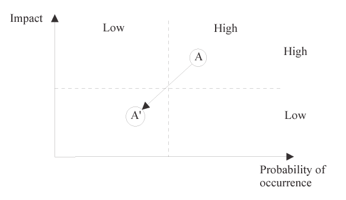

- A is the current level and A’ is the residual level
- Probability axis doesn’t have to be continuous, can be broad like low/mid/high

*Benefits*

- Get people together across org. to **talk about risk**
- *Improves* the enterprise’s **understanding** of the risk it faces
- *Improves* the **effect of its RM activities**
- Shows which **risk require further attention**
- Excellent **visual tool for reporting** to the Board on risk
- Can show before (**inherent risk**) and after (**residual risk**) to highlight the **effectiveness of its risk control**

### Control Effectivenss - Heat Maps

Plot **risk severity** against **control effectiveness** to show where action needs to be taken

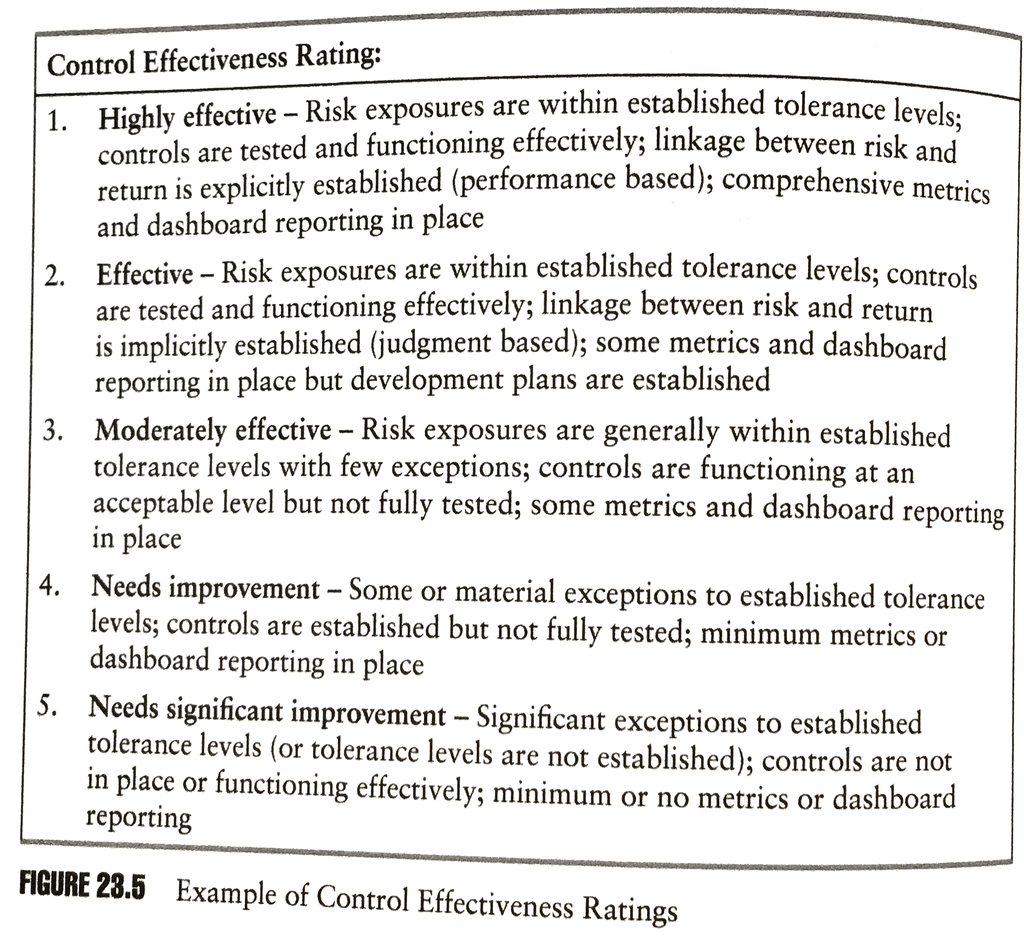

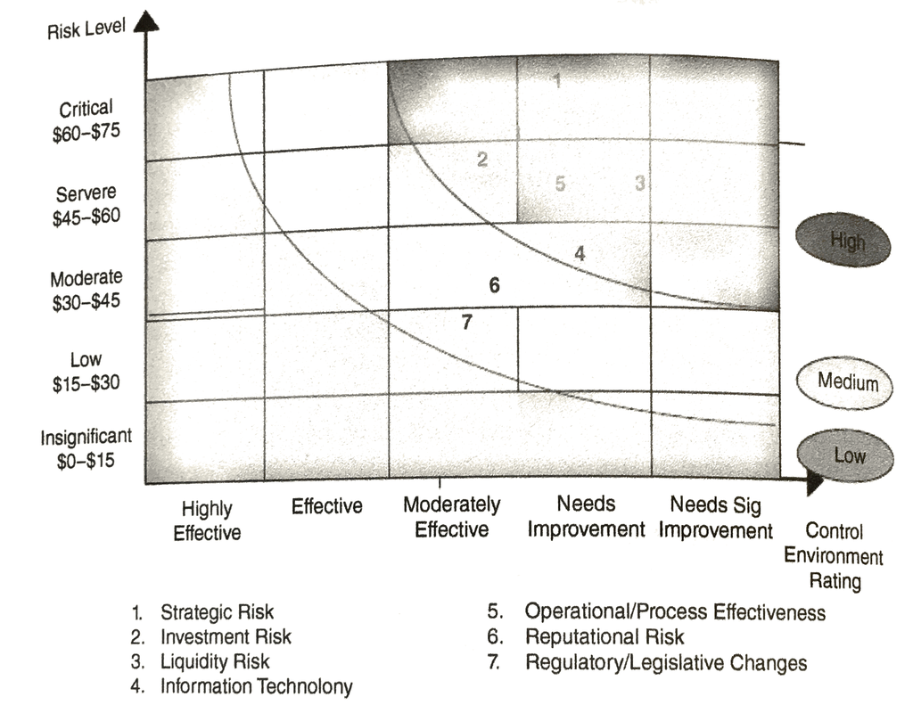

*Factors to rank risk controls* according to their perceived **effectiveness**

- Risk exposures are **within tolerance** levels
- **Controls are in place**
- Risks are **linked to potential impact on return**
- **Risk metrics/dashboard reporting** is established

## Emerging Risks

Emerging risks are important and need to be fed into the overall control cycle along with any other external events and influences

**Definition**:  
**Developing** of already known risks which are subject to *uncertainty* and *ambiguity* and are therefore difficult to quantify using traditional risk assessment techniques

- $\Delta$ **nature of an existing** or **known risk**, or
- $\Delta$ **underlying effectiveness** of risk management approaches of an existing or known risk, or
- **Development of a new risk**  
  (No explicit allowance in existing framework)

  Generally with much higher level of uncertainty

*Reasons why emerging risks are importants*:

- Knowledge of such risks will **influence corporate strategy**
- May **affect the profitability** of the organization
- May yield **opportunities for a new product**

*4 Key inter-related trends* that give rise to emerging risk management challenges

- **Globalization**:

  Increased **interdependence** of the world’s economies and market
- **Technology**:

  **New operational risks** from technology driven business
- **Changing market structures**:

  As markets are **deregulated and privatized**
- **Restructuring**:

  Effects of M&A and acquisition, joint ventures, outsourcing and business re-engineering

### Examples

Emerging risks of the past are known risks today  
(e.g. cost of guaranteed annuity rates, health damage from asbestos)

Emerging risk could include *potential impact* of:

- Significant **shift in power** between *world economies* (and collapse of previously secure nations)
- **Contagion** in asset markets
- **Claims from unexpected sources**
  - Nanotech
  - Mobile phone use
  - GMO food
  - Cyber
  - Terrorism (shifts in level and sources)
  - Climate change
  - Prolonged power blackouts
  - Emerging infectious and pandemic diseases
  - Unexpected changes in mortality or longevity
  - etc.
- Change in ways **information** is **stored** and **distributed** due to social media
- **Unexpected behavior** of **financial guarantees embedded products**
- **Non linear dependencies** between current known risks

### Emerging IT Risks

Due to increase reliance on computers and internet

1. *Cyber security*

   Cyber crimis rapidly evolving and becoming increasing sophisticated (crime involving the use of a computer over a network)
   - **Financial theft**:

     e.g. hacker accessing bank accounts to steal money
   - **Data theft**:

     e.g. accessing customer data, confidential business information or proprietary technology
   - **Attempts to disrupt a business**:

     e.g. Denial of service attacks
2. *Cloud computing*

   Use of external computing resources (hardware, software, and data) in order to reduce costs and provide more flexible and efficient computing
   - Shares similiar risk to outsourcing
   - Reduce amount of control over the data and increases the reliance on the risk management capabilities of the 3<sup>rd</sup> party provider
3. *Social media*

   Rise of social media offers upside opportunities including acting as an early warning indicator of emerging issues

   Introduces new risks
   - May open door for viruses and malware to be easily introduced to corporate network
   - Reputational risk is increased as brand image can be rapidly destroyed by a careless communication
   - Productivity maybe impared as employees become distracted by social media

### Identification and Analysis

Additional issues arise from emerging risk than the standard process (identification, analysis, etc)

- Need a more **holistic view** to identify emerging risk
- Need to **consider all possible impacts** of the new risk before it can be reduced to the more structured approach like the other risk

*Horizon Scanning*

- Key tool for identifying emerging risk
- Systematic search for potential developments over the longer term
- Emphasis on **changes that are at the edges of current thinking**
- **Requires input from experts** that understand the underlying drivers and the tech/science/econ/socioecon aspects
  - Alternatively (expert not available or too costly) can rely on relevant external sources (e.g. academic journals)

*Weighing different underlying evidence*

- There won’t be definitive study on the emerging risk

  $\therefore$ need to assess from different angles and sources
- Need to weight RM decisions according to the credibility and reliability of the underlying evidence
- Important to **continue monitor developments** in relevant research to refresh past decisions
- **Beware of alarmist media reports**
  - Useful for alerting of potential areas of further investigation
  - Should not be used as a basis for decision making

*Additional source of uncertainty*

- Added layer of uncertainty for companies impacted by likely **future legal approaches** to the emerging factors

  Active identification and consideration of such emerging risks will ready company to meet and react to such risks
- Analysis of **trends** is important
  - **Monitor regulatory and lobbying activity** in the sector by relevant experts
  - Important to **keep dependencies in mind** as changes can lead to reduction in diversification

## Bias

*Problem of bias*:  
Risks not being identified, assessed or reported in a true and honest way

- Can be due to **lack of supportive risk culture** (o rsub optimal culture)
- Often in the context of **project appraisal**

### Sources of Bias

*Intentional* bias:  
e.g. deliberate underestimation of risk to achieve a specific personal goal

*Unintentional* bias:  
e.g. inaccurate assessment of risk due to lack of experience or time

*Encountering bias*:

- Reporting to the Board about the ongoing risks facing the enterprise
- Project appraisal where the project champions tend to minimize the risks in hope of getting approval

*Ways in which bias are introduced into project appraisal* (by accident or design):

- Insufficient care to the identification or analysis of risk
- Omission of key risks (Accidental or deliberate)
- Incorrect assumptions of independence
- Underestimate likelihood due to inadequate past experience
- Deliberately over optimistic cash flows (or just guessing)
- Not accounting for future economic cycle
- Inadequate attention to risk with new technologies
- Not considering all the effects of the project on the sponsor’s other business
- Credit taken for benefits not directly attributable to the project
- Assumptions not correspond with sr mgmt’s view of the world in the future
- Spreadsheets error lead to failures of logic

### Behavioral Finance

Study of *unintentional bias in finance*

- Looks at how a variety of **mental biases** and **decision making errors** affect financial decisions
- Relates to the psychology that underlies and drives financial decision making behavior
- Evidence suggest that investors do not always act rationally contrary to tradtional economic theory assumptions

*3 types of behavioral bias*

1. *Overconfidence*:

   People Tend to overestimate their own abilities, knowledge and skills
2. **Anchoring**:

   People based perceptions on past experience or “expert” opinion
3. **Representative heuristics**:

   People find more probable those things that they find easier to imagine

[Other examples](http://www.sias.org.uk/view_paper?id=BehaviouralFinance)

### Avoiding Bias

**Built in checks and balances** can prevent the danger above

*Key step to minimize the risk of bias*:

- **Validate the appraisal work** (esp. cash flow) by competent and independent checking
- **Reference** where possible to the outcomes of **similar projects**

*Build in additional capital cost*:

- **Load in a %** to the capital cost based on past experience
- **Reduce estimated return**
  - **Caveat**:

    If the project is to proceed, it give the PMO a large contingency allowance in the capital cost  
    $\therefore$ reducing incentives to keep capital costs to a minimum